# Loan Calculator Pitch

## Amortization Calculator

A Loan calculator is a tool that helps a user estimate a monthly payment on an installment loan. The purpose of this tool is to make it easy for a user to make small adjustments to the amount of the loan, the length of time, and the interest rate–and receive instant feedback on the effect that those inputs will have on the monthly payment amount.

The frequency of interest compounding can have a very profound effect, and this tool will help show the difference in a loan that compounds monthly vs yearly compounding.

## Demo of Underlying Function

```r
am_calc_cm <- function(amount, term_len, int_rate) {
    term_mon <- term_len * 12
    ir_per <- int_rate / (100 * 12)
    output_payment <- amount *
        (((ir_per * (1+ir_per)^term_mon) /
        (((1+ir_per)^term_mon) - 1)))
    output_payment
}
am_calc_cy <- function(amount, term_len, int_rate) {
    ir_per <- int_rate / 100
    output_payment <- amount *
        (((ir_per * (1+ir_per)^term_len) /
        (((1+ir_per)^term_len) - 1)))
    output_payment / 12
}
```

## Demo of Function Output

```r
amount <- 5000
term_len <- 7
int_rate <- 13.9
am_calc_cm(amount, term_len, int_rate)
```

```
## [1] 93.42
```

```r
am_calc_cy(amount, term_len, int_rate)
```

```
## [1] 96.87
```

The function takes the term length parameter in years, and the interest rate in a percentage decimal number. Then the function itself converts the term length from years to months and the interest rate from a percentage to a straight floating point rate before making the final calculation of monthly payment amount.

## Effect of Interest

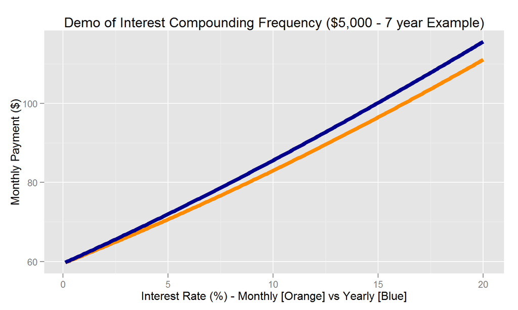

From the example on the previous slide, we can chart the effect of a range of interest rates to see the difference in compounding cycles across the range on interst rates.